# Samsung Galaxy S II Smartphone Analysis

Kim Kirk

December 15, 2017

# Samsung Galaxy S II Smartphone Analysis

### Analysis of accelerometers from Samsung Galaxy S smartphone

### Synopsis

A descriptive multivariate data analyis was conducted on the accelerometers data from the Samsung Galaxy S smartphone. Accelerometers include triaxial acceleration from the accelerometer (total acceleration) and the estimated body acceleration, triaxial Angular velocity from the gyroscope; with 561 variables with time and frequency domain data, activity labels, and identifiers of the subject who carried out the experiment. 7 data sets from UC Irvine Center for Machine Learning and Intelligent Systems were imported, merged, cleaned, and analyzed. The average was calculated for mean and standard deviation for each variable for each subject’s activity.

#### Data Processing

Five training and test data sets are downloaded as text files from the specified URL and loaded into R as vectors. Two training and test data sets are downloaded as text files from the specified URL and loaded into R as data frames.

```r
##set file path to save download to
path <- file.path(paste(getwd(), 'getdata_projectfiles_UCI HAR Dataset.zip', sep = "/"))
##set url for download
url <- "https://d396qusza40orc.cloudfront.net/getdata%2Fprojectfiles%2FUCI%20HAR%20Dataset.zip"

##download file and save to working directory
download.file(url, path)

##unzip file and put it in user's current working directory
chooseFile<-file.choose()
workingDir<-getwd()
unzip(chooseFile,exdir = workingDir)
##set working directory to inside of unzipped folder
setwd(paste(getwd(), 'UCI HAR Dataset', sep = "/"))

##import "features" as vector
features_labels <- scan("./features.txt", what = "text", sep = "\t")

##import "y_test" as vector
test_activities <- scan("./test/y_test.txt", what = "numeric", sep = "\t")
test_activities <- as.numeric(test_activities)

##import "y_train" as vector
train_activities <- scan("./train/y_train.txt", what = "numeric", sep = "\t")
train_activities <- as.numeric(train_activities)

##import "subject_test" as vector
test_subjects <- scan("./test/subject_test.txt", what = "numeric", sep = "\t")
test_subjects <- as.numeric(test_subjects)

##import "subject_train" as vector
train_subjects <- scan("./train/subject_train.txt", what = "numeric", sep = "\t")
train_subjects <- as.numeric(train_subjects)

##import "X_test" file
test_features <- read.table("./test/X_test.txt", header = FALSE, col.names = features_labels, na.strings = c(" ", "NA"), stringsAsFactors = FALSE, strip.white = TRUE, colClasses = "numeric")

##import "X_train" file
train_features <- read.table("./train/X_train.txt", header = FALSE, col.names = features_labels, na.strings = c(" ", "NA"), stringsAsFactors = FALSE, strip.white = TRUE, colClasses = "numeric")

##create vector to use as labels input for factors
factors_labels <- c("WALKING", "WALKING_UPSTAIRS", "WALKING_DOWNSTAIRS", "SITTING", "STANDING", "LAYING")
```

Test data and training data is converted to factors and merged with the features vector.

```r
##convert test_activities and test_subjects to factors
##bind test_activities to factors and features vector
test_bind_final <- cbind(factor(test_subjects, labels = c("Subject 2", "Subject 4", "Subject 9", "Subject 10", "Subject 12", "Subject 13", "Subject 18", "Subject 20", "Subject 24")),
    cbind(factor(test_activities, labels = factors_labels), test_features))

##convert train_activities and train_subjects to factors
##bind train_activities to factors and features vector
train_bind_final <- cbind(factor(train_subjects, labels = c("Subject 1", "Subject 3", "Subject 5", "Subject 6", "Subject 7", "Subject 8", "Subject 11", "Subject 14", "Subject 15", "Subject 16", "Subject 17", "Subject 19", "Subject 21", "Subject 22", "Subject 23", "Subject 25", "Subject 26", "Subject 27", "Subject 28", "Subject 29", "Subject 30")),
    cbind(factor(train_activities, labels = factors_labels), train_features))
```

First and second features of the merged test and training data sets are renamed to improve human readablility following tidy data principles.

```r
##rename first and second variable of test_bind_final to be more human readable
colnames(test_bind_final)[2] <- "activities"
colnames(test_bind_final)[1] <- "subject"

##rename first and second variable of train_bind_final to be more human readable
colnames(train_bind_final)[2] <- "activities"
colnames(train_bind_final)[1] <- "subject"
```

The testing data set and training data set are merged together to create the complete data set.

```r
##bind test and train datasets together
combined_test_train_datasets <- rbind(test_bind_final, train_bind_final)
```

Packages for tidying, analyzing, and visualizing data are loaded.

```r
##check for package, prompt user to download if no required package, load library
##credit Matthew on StackOverflow https://stackoverflow.com/users/4125693/matthew
using<-function(...) {
    libs<-unlist(list(...))
    req<-unlist(lapply(libs,require,character.only=TRUE))
    need<-libs[req==FALSE]
    n<-length(need)
    if(n>0){
        libsmsg<-if(n>2) paste(paste(need[1:(n-1)],collapse=", "),",",sep="") else need[1]
        print(libsmsg)
        if(n>1){
            libsmsg<-paste(libsmsg," and ", need[n],sep="")
        }
        libsmsg<-paste("The following packages could not be found: ",libsmsg,"\n\r\n\rInstall missing packages?",collapse="")
        if(winDialog(type = c("yesno"), libsmsg)=="YES"){
            install.packages(need)
            lapply(need,require,character.only=TRUE)
        }
    }
}
using("dplyr")
using("stringr")
using("RColorBrewer")
```

#### Analysis

Accelerometer averages for each feature that includes mean and standard deviation is found and grouped by each subject’s activity.

```r
##return columns for "subject", "activities", "mean", and "std"
##calculate mean for each "features" variable grouped by subject and activity
final_tidy_data <- combined_test_train_datasets %>% select(subject, activities, matches("mean"), matches("std")) %>%
    group_by(subject, activities) %>% summarise_if(is.numeric, mean, na.rm = TRUE)
```

#### Conclusion

A barplot is created for each subject by activity and accelerometers’ average value for mean and standard deviation.

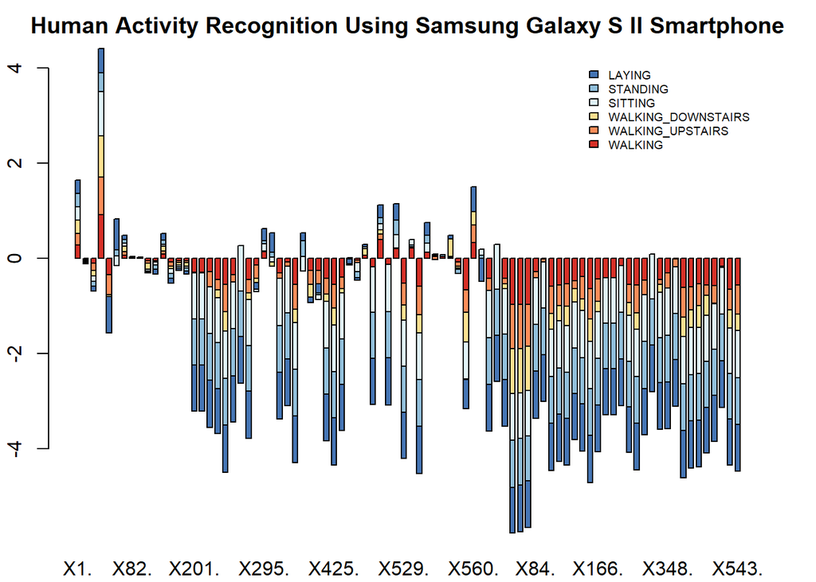

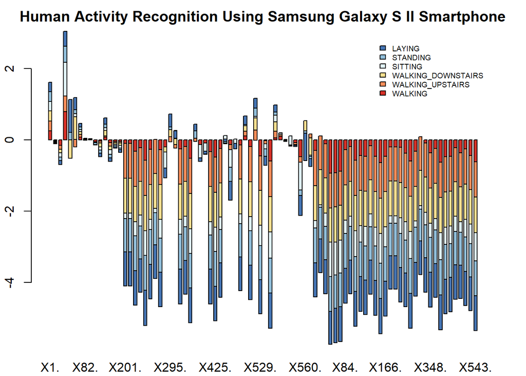

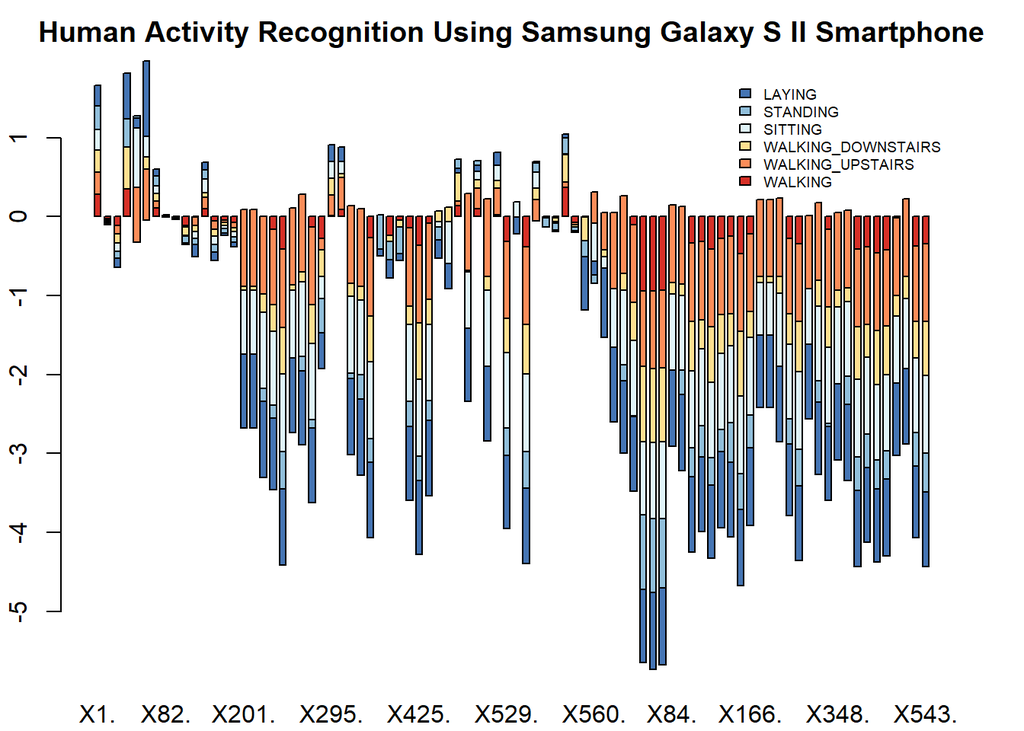

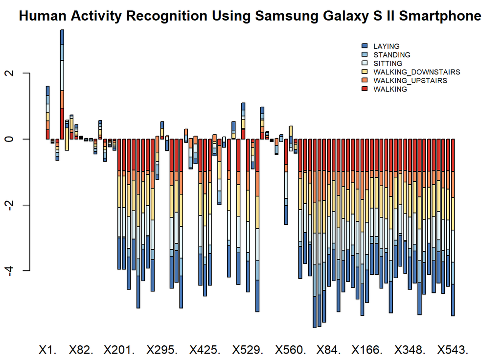

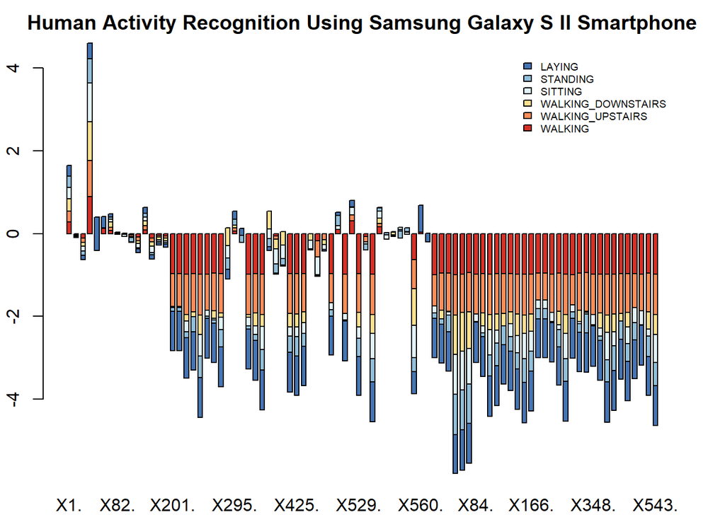

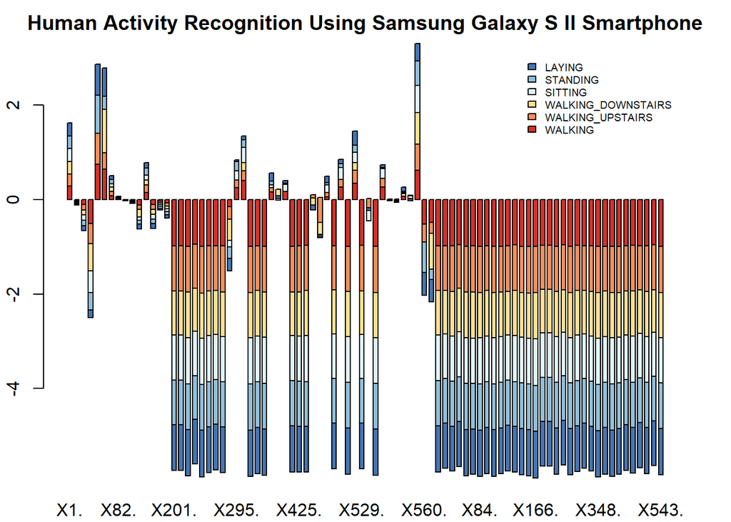

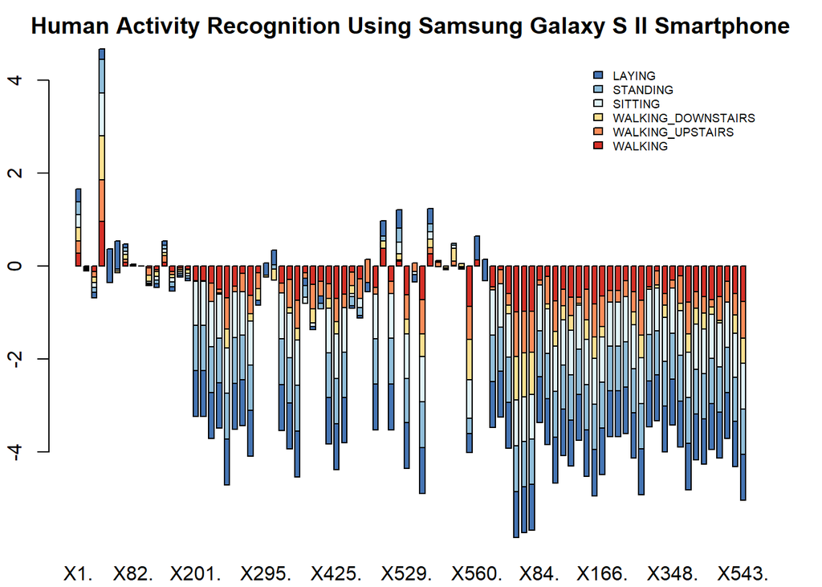

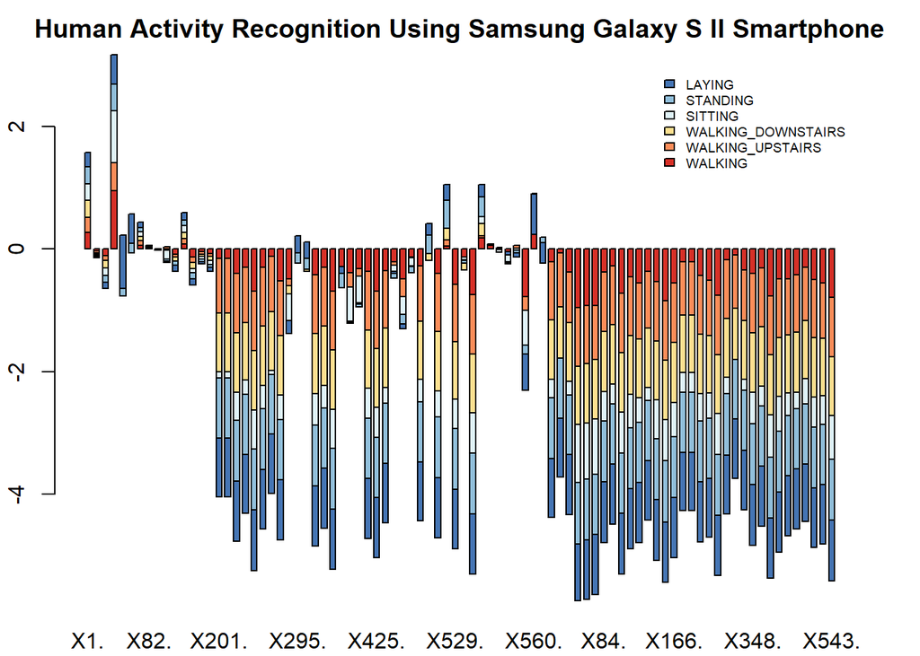

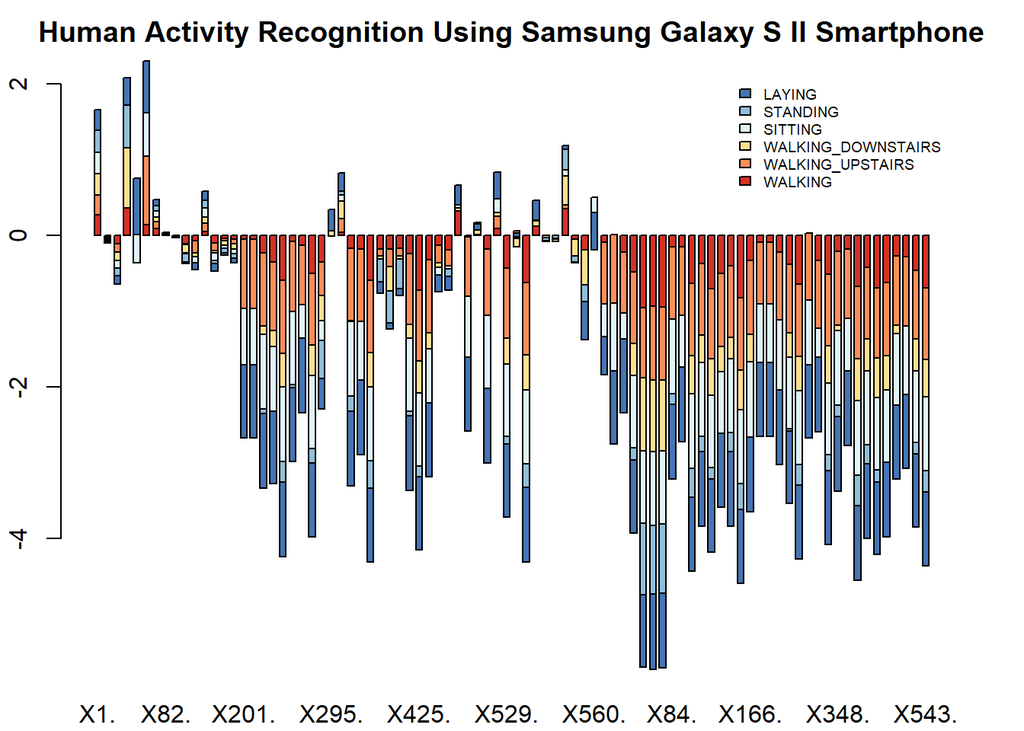

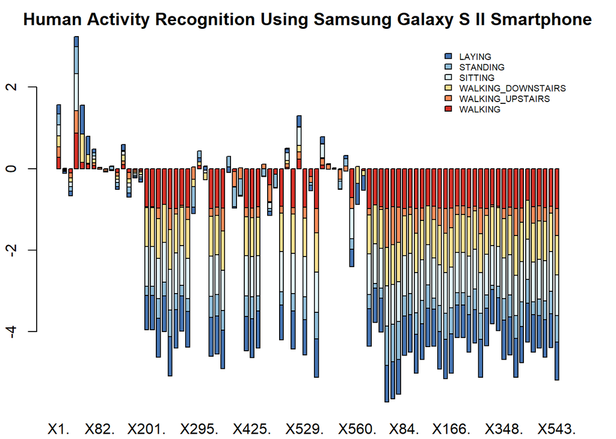

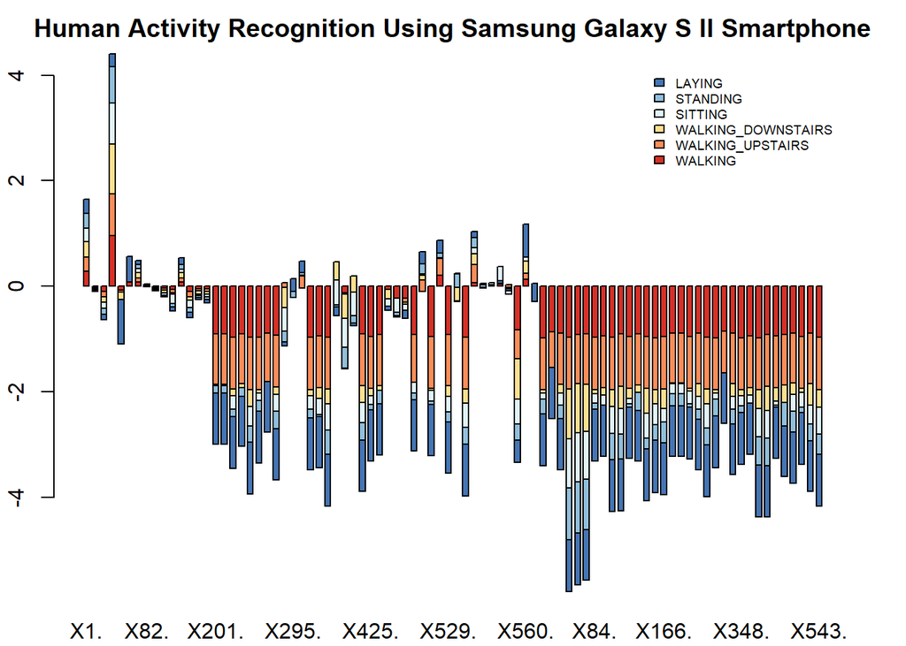

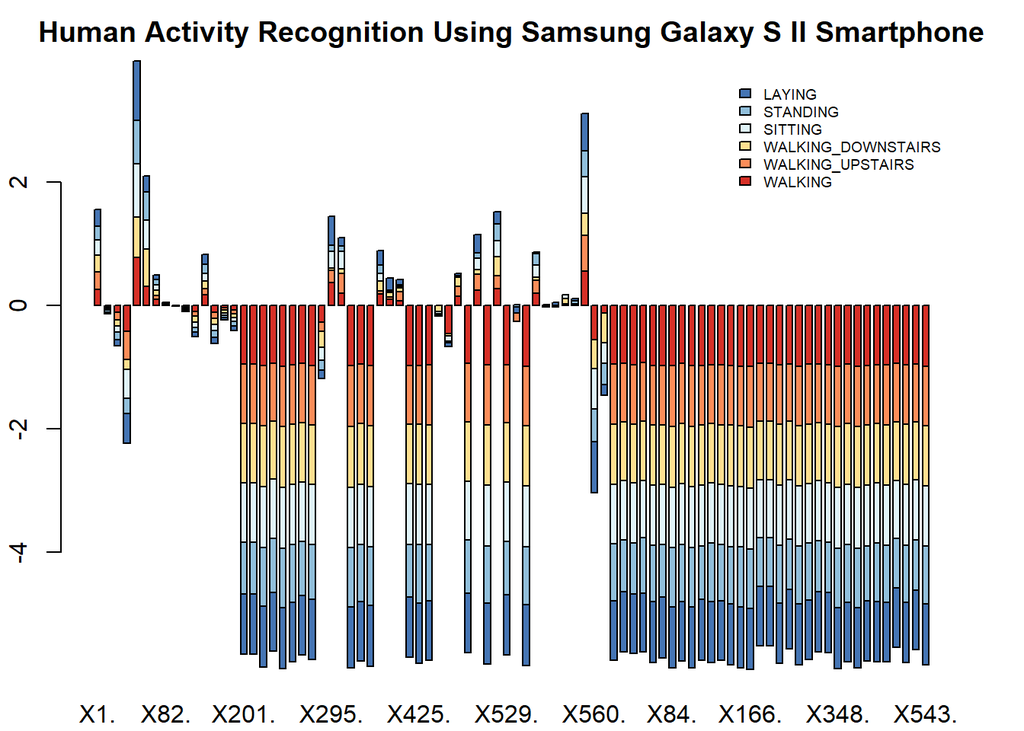

[18 more figures not shown]

```r
##row counter
j <- 1
##subjects counter
subjects <- as.vector(as.matrix(unique(final_tidy_data[,1])))
##Let's set the universal properties of the graphic so
    ##that each plot fits nicely on its own screen so that all variables
    ##can be clearly seen and the legend is not obscured.
par(mfrow= c(1,1), mar =  c(2.1, 2.1, 2.1, 2.1))
##for each value in the "subjects" vector subset the appropriate rows and
    ##columns then plot a barplot.
for(subject in subjects ) {
    ##go to dataset
    ##pull out 6 rows and all columns from 3 to the entire length of the data set
    matrix_final_tidy_data <- final_tidy_data[1:6 * j,3:length(final_tidy_data) ]
    ##create a barplot
    barplot(as.matrix(matrix_final_tidy_data), main = "Human Activity Recognition Using Samsung Galaxy S II Smartphone",
            sub = subject,
            xlab = "Feature Variable Label",
            ylab = "Standard Gravity Units (g)",
            legend.text = factors_labels,
            args.legend = list("topright", inset = .0001, bty = "n", cex=0.6),
            names.arg =  str_extract(colnames(matrix_final_tidy_data), "^X[0-9]*\\."),
            col = brewer.pal(n=6,name="RdYlBu"),
            space = 0.5
    )
    ##increment the row counter by 1
    j <- j + 1

}
```